# Big Chico Creek

Sadie Gill, Mark Tompkins

July 1, 2019

## Floodplain Modeling Details

**Data Source:** [Central Valley Floodplain Evaluation and Delineation (CVFED) HEC-RAS hydraulic model](https://s3-us-west-2.amazonaws.com/cvpiahabitat-r-package/cvpia-sit-model-inputs/CombinedTM_IQAR_Final-FULL-REPORT_20140206.pdf)

### Fall Run

A 8.7 mile portion of the entire mapped rearing extent of 15.1 miles was modeled using Central Valley Floodplain Evaluation and Delineation (CVFED) HEC-RAS hydraulic model. Of the entire mapped rearing extent, 15.1 miles were classified as low gradient and 0 miles were classified as high gradient based on a geomorphic analysis. Floodplain area per unit length was determined for the modeled extent and applied to determine areas for the non-modeled extent. A scaling factor of 0.1 was applied to the area per unit length for the high gradient extent. No scaling factor was applied to the low gradient extent.

### Spring Run and Steelhead

A 8.7 mile portion of the entire mapped rearing extent of 23.8 miles was modeled using Central Valley Floodplain Evaluation and Delineation (CVFED) HEC-RAS hydraulic model. Of the entire mapped rearing extent, 15.1 miles were classified as low gradient and 8.8 miles were classified as high gradient based on a geomorphic analysis. Floodplain area per unit length was determined for the modeled extent and applied to determine areas for the non-modeled extent. A scaling factor of 0.1 was applied to the area per unit length for the high gradient extent. No scaling factor was applied to the low gradient extent.

## Floodplain Data

| flow_cfs | FR_floodplain_acres | SR_floodplain_acres | ST_floodplain_acres | watershed |
| --- | --- | --- | --- | --- |
| 1215 | 0.000000 | 0.000000 | 0.000000 | Big Chico Creek |
| 1265 | 1.605321 | 1.699004 | 1.699004 | Big Chico Creek |
| 1315 | 4.209542 | 4.455202 | 4.455202 | Big Chico Creek |
| 1365 | 6.788936 | 7.185124 | 7.185124 | Big Chico Creek |
| 1415 | 10.011005 | 10.595226 | 10.595226 | Big Chico Creek |
| 1465 | 13.039604 | 13.800567 | 13.800567 | Big Chico Creek |
| 1515 | 15.689879 | 16.605507 | 16.605507 | Big Chico Creek |

## Floodplain Plot

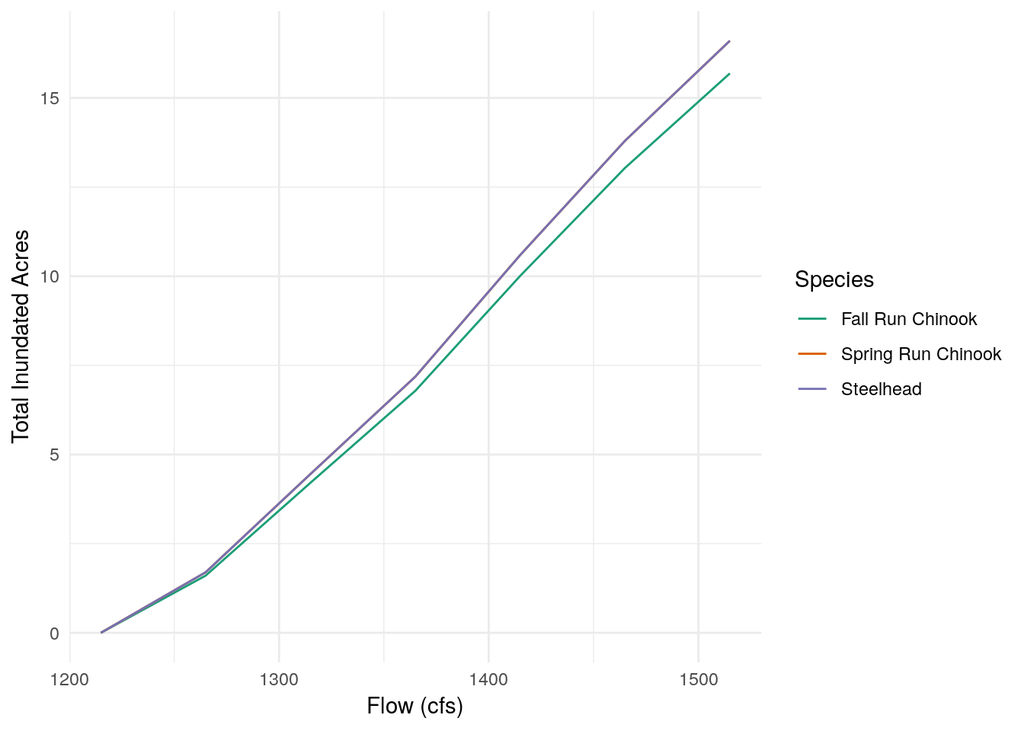